# Bakery Transaction Data Analysis

Edward Yu

2018-11-17

# 1 Introduction

What we have here is a few months worth of sales data from a bakery.

The original dataset was put on Kaggle but deleted: https://www.kaggle.com/deleted-dataset/50231.

Fortunately someone reuploaded the data: https://www.kaggle.com/sulmansarwar/transactions-from-a-bakery.

What we’ll be doing in my first kernel is a little exploratory data analysis (EDA) followed by a Market Basket Analysis (MBA).

## 1.1 Load packages, check data

Let’s install the required packages we’ll be using.

```r
if (!require(tibble)) install.packages("tibble")
library(tibble)
if (!require(tidyverse)) install.packages("tidyverse")
library(tidyverse)
if (!require(lubridate)) install.packages("lubridate")
library(lubridate)
if (!require(viridis)) install.packages("viridis")
library(viridis)
if (!require(ggthemes)) install.packages("ggthemes")
library(ggthemes)
if (!require(gridExtra)) install.packages("gridExtra")
library(gridExtra)
if (!require(ggridges)) install.packages("ggridges")
library(ggridges)
if (!require(arules)) install.packages("arules")
library(arules)
if (!require(arulesViz)) install.packages("arulesViz")
library(arulesViz)
```

And get an idea of what our data holds, and the structure of the data.

```r
x <- read.csv("data/BreadBasket_DMS.csv") %>%
  mutate(Date=as.Date(Date),
         Time=hms(Time)
         )
summary(x)
```

```
##       Date                 Time                            Transaction
##  Min.   :2016-10-30   Min.   :1H 21M 5S                   Min.   :   1
##  1st Qu.:2016-12-03   1st Qu.:10H 56M 40S                 1st Qu.:2548
##  Median :2017-01-21   Median :12H 37M 30S                 Median :5067
##  Mean   :2017-01-17   Mean   :12H 45M 1.40125862959394S   Mean   :4952
##  3rd Qu.:2017-02-28   3rd Qu.:14H 29M 37S                 3rd Qu.:7329
##  Max.   :2017-04-09   Max.   :23H 38M 41S                 Max.   :9684
##
##       Item
##  Coffee :5471
##  Bread  :3325
##  Tea    :1435
##  Cake   :1025
##  Pastry : 856
##  NONE   : 786
##  (Other):8395
```

```r
glimpse(x)
```

```
## Observations: 21,293
## Variables: 4
## $ Date        <date> 2016-10-30, 2016-10-30, 2016-10-30, 2016-10-30, 2...
## $ Time        <S4: Period> 9H 58M 11S, 10H 5M 34S, 10H 5M 34S, 10H 7M ...
## $ Transaction <int> 1, 2, 2, 3, 3, 3, 4, 5, 5, 5, 6, 6, 6, 7, 7, 7, 7,...
## $ Item        <fct> Bread, Scandinavian, Scandinavian, Hot chocolate, ...
```

Right off the bat we see our time period is relatively narrow: taken between the dates of 2016-10-30 and 2017-04-09.

In other words, we have only 161 days worth of data.

```r
difftime(x$Date[nrow(x)],x$Date[1])
```

```
## Time difference of 161 days
```

# 2 Exploration

Let’s see what we can glean looking at various manipulations of the data we have available.

## 2.1 Item frequency

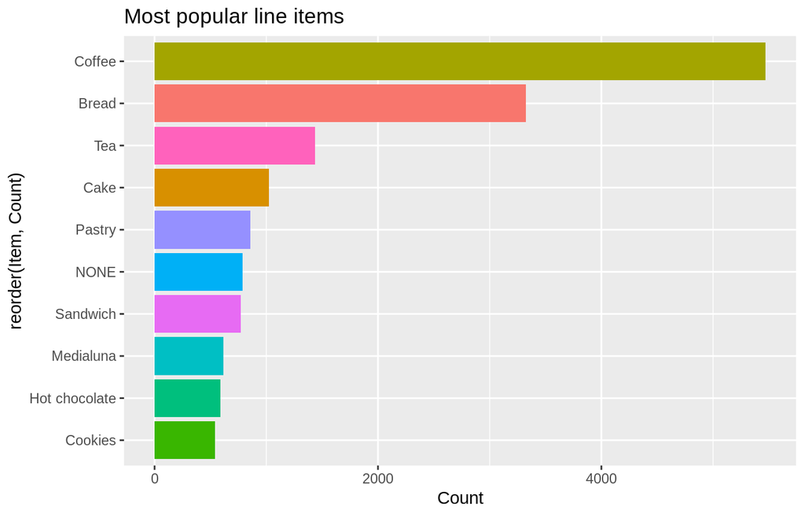

```r
x1 <- x %>%
  group_by(Item) %>%
  summarise(Count = n()) %>%
  arrange(desc(Count)) %>%
  slice(1:10) %>% # keep the top 10 items
  ggplot(aes(x=reorder(Item,Count),y=Count,fill=Item))+
  geom_bar(stat="identity")+
  coord_flip()+
  ggtitle("Most popular line items")+
  theme(legend.position="none")
x1
```

No real surprises with frequency, although the `NONE` is slightly odd. It should be noted that when using `count` we’re adding all instances of that particular item. We are not discriminating between different sales receipts. So if one person has ordered 5 coffees, we count coffee 5 times rather than once. Right now this doesn’t bother me, we can look at it later on.

# 3 Sales over time

We have an idea of what we’re selling so now let’s plot it against our various measures of time. Each transaction lists both time and date, we’ll first take a large step back and look at sales over all time, followed by a closer daily look.

## 3.1 All time

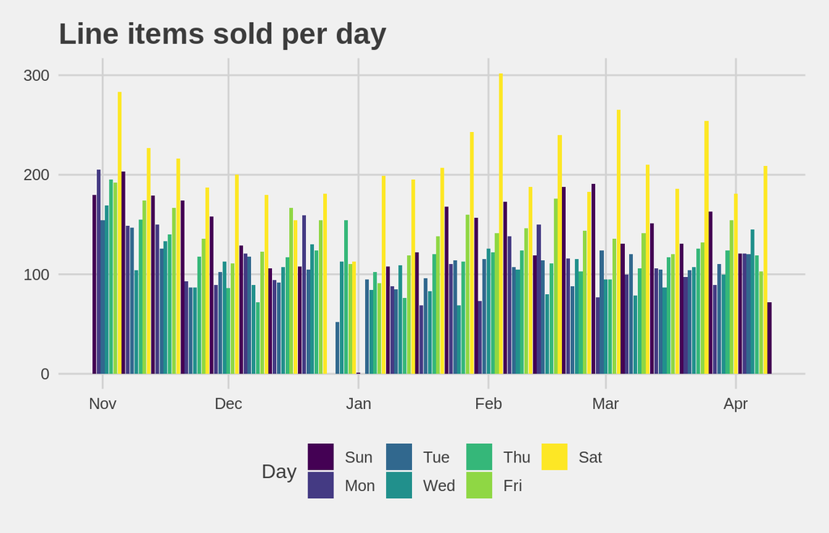

```r
# Line items sold per day
x2 <- x %>%
  group_by(Date) %>%
  summarise(Count= n()) %>%
  mutate(Day=wday(Date,label=T)) %>%
  ggplot(aes(x=Date,y=Count,fill=Day))+
  theme_fivethirtyeight()+
  geom_bar(stat="identity")+
  ggtitle("Line items sold per day")+
  scale_fill_viridis(discrete=TRUE)
x2
```

Plotting total line items sold per day shows some obvious peaks and valleys. Saturday is the big sales day for this bakery, followed by Sunday.

## 3.2 Weekly

Let’s zoom in a little bit to take a closer look. Let’s try a weekly view by stacking total sales based on weekday sold.

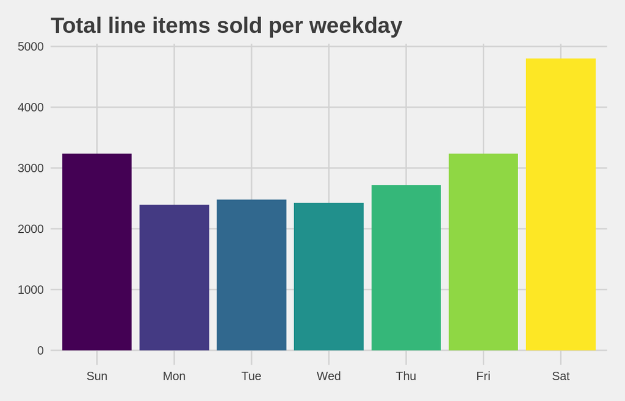

```r
# Total line items sold per weekday
x3 <- x %>%
  mutate(Day = wday(Date,label=T)) %>%
  group_by(Day) %>%
  summarise(Count= n()) %>%
  ggplot(aes(x=Day,y=Count,fill=Day))+
  theme_fivethirtyeight()+
  geom_bar(stat="identity")+
  ggtitle("Total line items sold per weekday")+
  theme(legend.position="none")
x3
```

We confirm the general pattern we saw above: our top sales days are on Saturdays, with Sundays and Fridays following behind. Mondays through Thursdays are all roughly similar in total line items sold. Essentially, we’ve averaged all values creating less drastic peaks as we saw above.

Maybe we should try making the differences more drastic for easier comparison? One approach might be to filter for top sales days first, and then add all total line items sold by weekday.

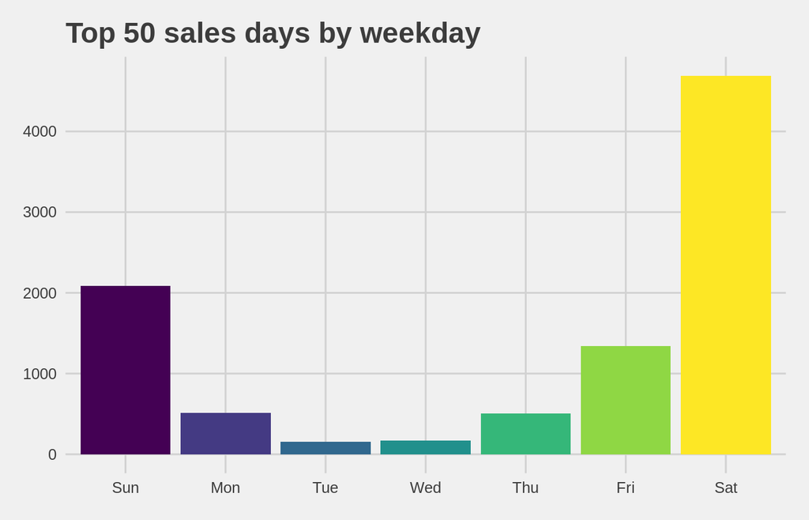

```r
# Top 50 transactions days per weekday
x6 <- x %>%
  group_by(Date) %>%
  summarise(Count= n()) %>%
  arrange(desc(Count)) %>%
  slice(1:50) %>%
  mutate(wday = wday(Date,label=T)) %>%
  ggplot(aes(x=wday,y=Count,fill=wday))+
  theme_fivethirtyeight()+
  geom_bar(stat="identity")+
  ggtitle("Top 50 sales days by weekday")+
  theme(legend.position="none")
x6
```

It’s clear that Saturdays are much more likely to be top sales days, followed by Sundays and Fridays. This graph could be slightly misleading though and if not interepreted correctly could lead to some false conclusions about how slow weekdays are when compared to the weekends (they aren’t as slow as this comparison makes out).

Let’s change direction. Remember we talked about line items versus unique sales? Let’s try filtering for distinct transactions and see how that changes things.

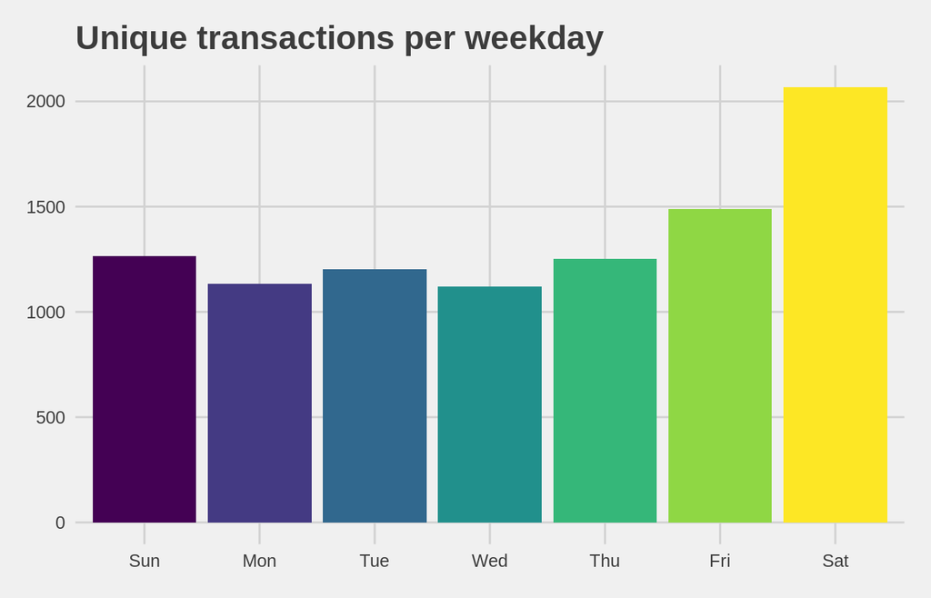

```r
# Total unique transactions per weekday
x4 <- x %>%
  mutate(wday=wday(Date,label=T)) %>%
  group_by(wday,Transaction) %>%
  summarise(n_distinct(Transaction)) %>%
  summarise(Count=n()) %>%
  ggplot(aes(x=wday,y=Count,fill=wday))+
  theme_fivethirtyeight()+
  geom_bar(stat="identity")+
  ggtitle("Unique transactions per weekday")+
  theme(legend.position="none")
x4
```

This is a more fare representation of ‘business’ throughout the week. Saturday is still the top dog. Sunday falls behind Friday, however, in contrast to what we saw above comparing line items. We might guess that on Sunday we have more generous customers buying for their friends, or even that Sunday tends to be a day when customers buy more than 1 or 2 items.

That does bring to mind a good question, how many items to people purchase on average?

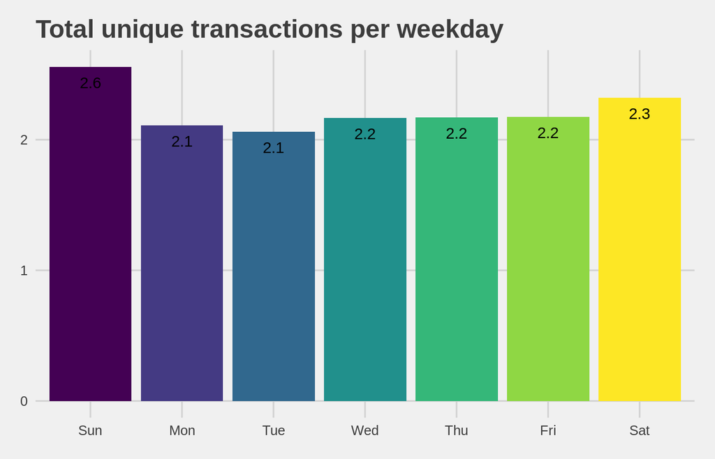

```r
x5.1 <- x %>%
  mutate(Day = wday(Date,label=T)) %>%
  group_by(Day) %>%
  summarise(Count= n())

x5.2 <- x %>%
  mutate(wday=wday(Date,label=T)) %>%
  group_by(wday,Transaction) %>%
  summarise(n_distinct(Transaction)) %>%
  summarise(Count=n())

x5.3 <- data.frame(x5.1, # Days, total items
                   x5.2[2], # unique transactions
                   x5.1[2]/x5.2[2])  # items per unique transaction
colnames(x5.3) <- c("Day","Line","Unique","Items.Trans")

ggplot(x5.3,aes(x=Day,y=Items.Trans,fill=Day))+
  theme_fivethirtyeight()+
  geom_bar(stat="identity")+
  ggtitle("Total unique transactions per weekday")+
  theme(legend.position="none")+
  geom_text(aes(label=round(Items.Trans,1)), vjust=2)
```

Indeed, people tend to buy more items on Sundays! We also have a slight increase for Saturdays as well when compared to the rest of the week.

Let’s zoom in further.

## 3.3 Hourly

We do a simple line items sold per hour plot and unsurprisingly see that most items are sold around lunch time.

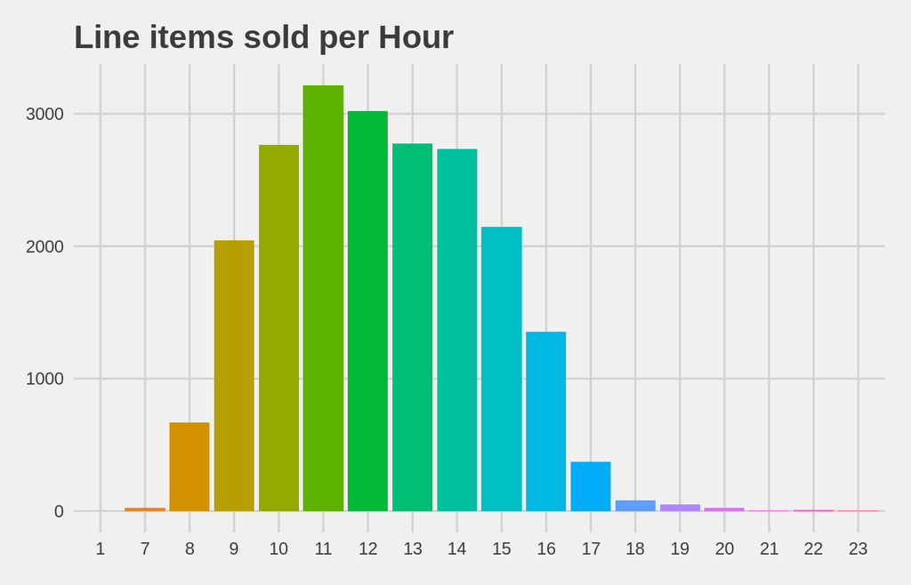

```r
# Line items sold per Hour
x7 <- x %>%
  mutate(Hour = as.factor(hour(x$Time))) %>%
  group_by(Hour) %>%
  summarise(Count=n()) %>%
  ggplot(aes(x=Hour,y=Count,fill=Hour))+
  theme_fivethirtyeight()+
  geom_bar(stat="identity")+
  ggtitle("Line items sold per Hour")+
  theme(legend.position="none")
x7
```

Can we learn anything about unique transactions, as we did above with the date data?

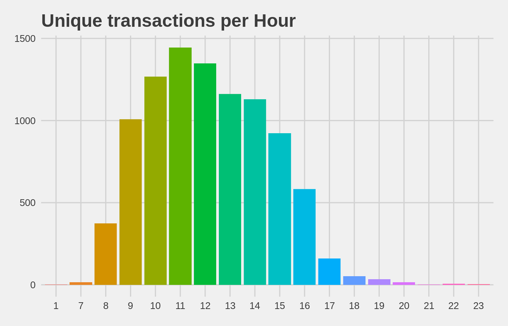

```r
# Unique transactions per Hour
x8 <- x %>%
  mutate(Hour = as.factor(hour(Time)))%>%
  group_by(Hour,Transaction) %>%
  summarise(n_distinct(Transaction)) %>%
  summarise(Count=n()) %>%
  ggplot(aes(x=Hour,y=Count,fill=Hour))+
  theme_fivethirtyeight()+
  geom_bar(stat="identity")+
  ggtitle("Unique transactions per Hour")+
  theme(legend.position="none")
x8
```

We really don’t see much of a differece besides scale. Again, let’s see how many items are bought with each transaction.

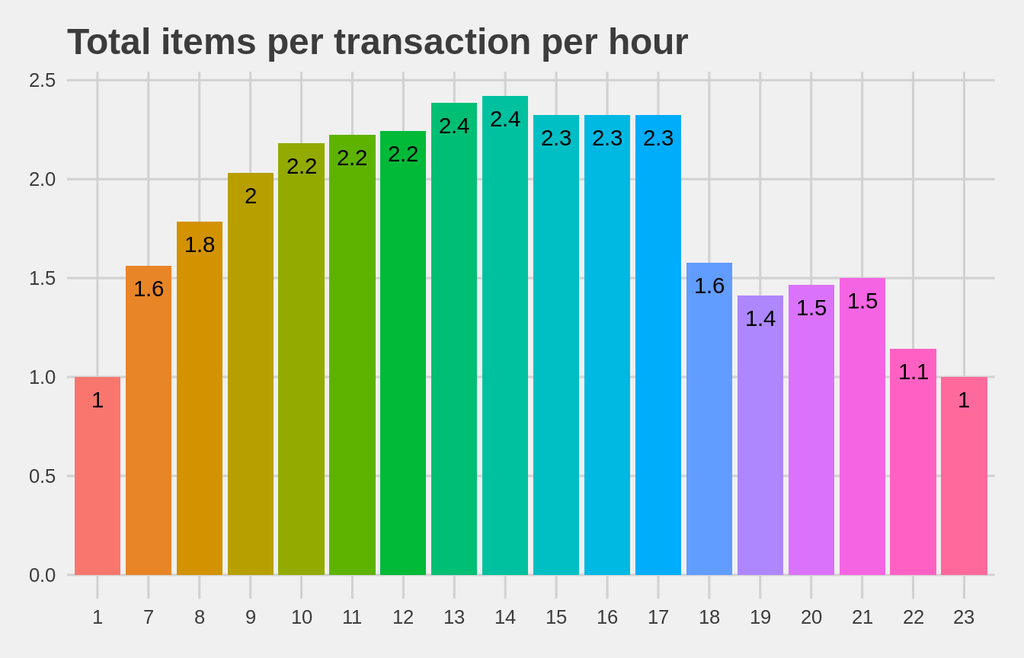

```r
x9.1 <- x %>%
  mutate(Hour = as.factor(hour(Time)))%>%
  group_by(Hour) %>%
  summarise(Count= n())

x9.2 <- x %>%
  mutate(Hour = as.factor(hour(Time)))%>%
  group_by(Hour,Transaction) %>%
  summarise(n_distinct(Transaction)) %>%
  summarise(Count=n())

x9.3 <- data.frame(x9.1, # Days, total items
                   x9.2[2], # unique transactions
                   x9.1[2]/x9.2[2])  # items per unique transaction
colnames(x9.3) <- c("Hour","Line","Unique","Items.Trans")

x9 <-
  ggplot(x9.3,aes(x=Hour,y=Items.Trans,fill=Hour))+
  theme_fivethirtyeight()+
  geom_bar(stat="identity")+
  ggtitle("Total items per transaction per hour")+
  theme(legend.position="none")+
  geom_text(aes(label=round(Items.Trans,1)), vjust=2)
x9
```

People buy the most items per transaction between 10am and 5pm, these seem likes standard hours people might walk in to grab a bite to eat. Before 10am most are likely buying a single item like coffee. Similarly with after 5pm.

## 3.4 Combination

Let’s see if we can visualize transaction density per hour for all days of the week using a ridge plot

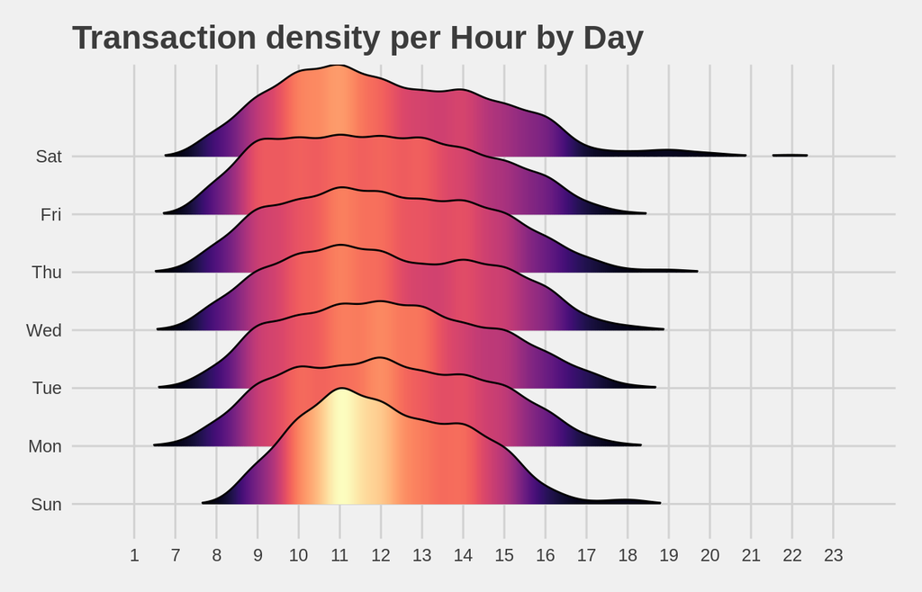

```r
x10 <- x %>%
  mutate(Hour=as.factor(hour(Time)),
         Day=wday(Date,label=T)) %>%
  group_by(Day,Hour,Transaction) %>%
  summarise(Count=n()) %>%
  ggplot(aes(x=Hour,y=Day,group=Day,fill=..density..))+
  theme_fivethirtyeight()+
  ggtitle("Transaction density per Hour by Day")+
  theme(legend.position="none")+
  geom_density_ridges_gradient(scale=2, rel_min_height=0.01)+
  scale_fill_viridis(option="magma")
x10
```

The ridge plot gives a nice summary of what we’ve seen in the above bar charts without overly distorting scales.

Saturday has a wider breadth and sees most transactions overall.

Sunday falls close being with Sunday lunch having the most dense transaction peak.

It’s time for a new take on the data using Market Basket Analysis.

# 4 Market Basket Analysis

Let’s import our transaction data to the appropriate format and check it out.

## 4.1 Import and peak

```r
y <- read.transactions("data/BreadBasket_DMS.csv",
                       format="single",
                       cols=c(3,4),
                       sep=","
                       )
summary(y)
```

```
## transactions as itemMatrix in sparse format with
##  6614 rows (elements/itemsets/transactions) and
##  104 columns (items) and a density of 0.02008705
##
## most frequent items:
##  Coffee   Bread     Tea    Cake  Pastry (Other)
##    3188    2146     941     694     576    6272
##
## element (itemset/transaction) length distribution:
## sizes
##    1    2    3    4    5    6    7    8    9   10
## 2556 2154 1078  546  187   67   18    3    2    3
##
##    Min. 1st Qu.  Median    Mean 3rd Qu.    Max.
##   1.000   1.000   2.000   2.089   3.000  10.000
##
## includes extended item information - examples:
##                     labels
## 1               Adjustment
## 2 Afternoon with the baker
## 3                Alfajores
##
## includes extended transaction information - examples:
##   transactionID
## 1             1
## 2            10
## 3          1000
```

We see our most frequent items agree with what we found above. And that most transactions are either one or two items, including 3 lucky people who apparently bought for the entire office.

If we want to visualize the frequent items using `arules` we can. We need to import our transaction data, and we can go ahead and reaffirm our previous findings by using the `itemFrequencyPlot` function to find the top 5 most popular items

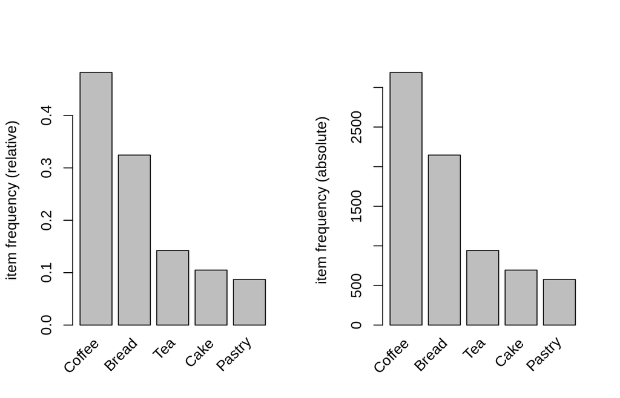

```r
par(mfrow=c(1,2))
itemFrequencyPlot(y,topN=5,type="relative")
itemFrequencyPlot(y,topN=5,type="absolute")
```

## 4.2 Support and Confidence

Now before we perform our MBA we need to determine reasonable values for the support and confidence values.

**Support:** An itemset with high support means it appears in our transactions frequently. High confidence is direclty related to the frequency an item appears. For example, coffee probably has very high support.

So let’s pin down our `support` value first.

```r
summary(itemFrequency(y))
```

```
##      Min.   1st Qu.    Median      Mean   3rd Qu.      Max.
## 0.0001512 0.0002646 0.0013607 0.0200871 0.0146659 0.4820079
```

Remember, item frequency is directly related to support. We can see the distribution of values above, with the max frequency at 0.4820079. This is probably coffee which we saw above appears greater than 40% of the time in purchases.

```r
30/length(y)
```

```
## [1] 0.004535833
```

## 4.3 Assign rules

Our support value will be roughly 0.0045. So what about confidence? Let’s use a cointoss as inspiration. Remember that confidence is the likelihood, having purchased the item on the LHS, that the item on the RHS will be purchased in addition. Let’s go with 50%, or a value of 0.5.

```r
rules <- apriori(y,parameter=list(support=0.0045,confidence=.5))
```

```
## Apriori
##
## Parameter specification:
##  confidence minval smax arem  aval originalSupport maxtime support minlen
##         0.5    0.1    1 none FALSE            TRUE       5  0.0045      1
##  maxlen target   ext
##      10  rules FALSE
##
## Algorithmic control:
##  filter tree heap memopt load sort verbose
##     0.1 TRUE TRUE  FALSE TRUE    2    TRUE
##
## Absolute minimum support count: 29
##
## set item appearances ...[0 item(s)] done [0.00s].
## set transactions ...[104 item(s), 6614 transaction(s)] done [0.00s].
## sorting and recoding items ... [39 item(s)] done [0.00s].
## creating transaction tree ... done [0.00s].
## checking subsets of size 1 2 3 4 done [0.00s].
## writing ... [20 rule(s)] done [0.00s].
## creating S4 object  ... done [0.00s].
```

```r
rules
```

```
## set of 20 rules
```

## 4.4 Inspect rules

We’re give a set of 20 rules, which is quite managable. Let’s take a look.

```r
inspect(head(rules,by="support",n=10))
```

```
##      lhs                rhs      support    confidence lift     count
## [1]  {Cake}          => {Coffee} 0.05654672 0.5389049  1.118042 374
## [2]  {Pastry}        => {Coffee} 0.04868461 0.5590278  1.159790 322
## [3]  {Sandwich}      => {Coffee} 0.04233444 0.5679513  1.178303 280
## [4]  {NONE}          => {Coffee} 0.04172966 0.5810526  1.205484 276
## [5]  {Medialuna}     => {Coffee} 0.03296039 0.5751979  1.193337 218
## [6]  {Cookies}       => {Coffee} 0.02978530 0.5267380  1.092800 197
## [7]  {Hot chocolate} => {Coffee} 0.02721500 0.5263158  1.091924 180
## [8]  {Toast}         => {Coffee} 0.02570305 0.7296137  1.513697 170
## [9]  {Alfajores}     => {Coffee} 0.02237678 0.5522388  1.145705 148
## [10] {Juice}         => {Coffee} 0.02131842 0.5300752  1.099723 141
```

Cake, pastry, and sandwich are most commonly bought in tandem with Coffee. Oddly, Juice is also frequently bought with Coffee… We can only assume that this is due to one person buying for another and hopefully not that some monster is drinking drinking both simultaneously.

```r
inspect(head(rules,by="confidence"))
```

```
##     lhs                     rhs      support     confidence lift     count
## [1] {Cake,Sandwich}      => {Coffee} 0.005594194 0.7551020  1.566576  37
## [2] {Toast}              => {Coffee} 0.025703054 0.7296137  1.513697 170
## [3] {NONE,Sandwich}      => {Coffee} 0.005140611 0.6415094  1.330911  34
## [4] {Spanish Brunch}     => {Coffee} 0.014061083 0.6326531  1.312537  93
## [5] {Cake,Hot chocolate} => {Coffee} 0.006501361 0.6323529  1.311914  43
## [6] {Salad}              => {Coffee} 0.007862111 0.6117647  1.269201  52
```

More interesting are the association rules. Sorting by confidence gives us items on the LHS that give a high chance of being bought together with the item on the RHS. When looking at purchases that contrain {Cake, Sandwich}, 75% of them also contain {Coffee}.

Considering the suppport or count values, the association of {Toast} => {Coffee} may be more useful.

What about lift?

```r
inspect(head(rules,by="lift"))
```

```
##     lhs                     rhs      support     confidence lift     count
## [1] {Cake,Sandwich}      => {Coffee} 0.005594194 0.7551020  1.566576  37
## [2] {Toast}              => {Coffee} 0.025703054 0.7296137  1.513697 170
## [3] {NONE,Sandwich}      => {Coffee} 0.005140611 0.6415094  1.330911  34
## [4] {Spanish Brunch}     => {Coffee} 0.014061083 0.6326531  1.312537  93
## [5] {Cake,Hot chocolate} => {Coffee} 0.006501361 0.6323529  1.311914  43
## [6] {Salad}              => {Coffee} 0.007862111 0.6117647  1.269201  52
```

## 4.5 Lift

The lift measure is related closely to the confidence measure.

**Lift** is the ratio of *Confidence* to *Expected Confidence*

A lift ratio larger than 1.0 implies the relationship between LHS and RHS is significant and not simply chance. The larger the lift ratio, the more significant the relationship between LHS and RHS. Our lift values are not incredibly high, though high enough to rule out random chance.

If we really want to find some high lift values we can refine our ruleset and adjust our support and confidence parameters.

```r
rules2 <- apriori(y,parameter=list(support=0.00045,confidence=.9))
```

```
## Apriori
##
## Parameter specification:
##  confidence minval smax arem  aval originalSupport maxtime support minlen
##         0.9    0.1    1 none FALSE            TRUE       5 0.00045      1
##  maxlen target   ext
##      10  rules FALSE
##
## Algorithmic control:
##  filter tree heap memopt load sort verbose
##     0.1 TRUE TRUE  FALSE TRUE    2    TRUE
##
## Absolute minimum support count: 2
##
## set item appearances ...[0 item(s)] done [0.00s].
## set transactions ...[104 item(s), 6614 transaction(s)] done [0.00s].
## sorting and recoding items ... [72 item(s)] done [0.00s].
## creating transaction tree ... done [0.00s].
## checking subsets of size 1 2 3 4 5 done [0.00s].
## writing ... [87 rule(s)] done [0.00s].
## creating S4 object  ... done [0.00s].
```

```r
inspect(head(rules2,by="lift",n=10))
```

```
##      lhs                                      rhs             support
## [1]  {Juice,Pick and Mix Bowls}            => {Mineral water} 0.0004535833
## [2]  {Bread,Scone,Truffles}                => {Mineral water} 0.0004535833
## [3]  {Bread,Mineral water,Truffles}        => {Scone}         0.0004535833
## [4]  {Mineral water,Pick and Mix Bowls}    => {Juice}         0.0004535833
## [5]  {Cookies,Hearty & Seasonal}           => {Hot chocolate} 0.0004535833
## [6]  {Cookies,Extra Salami or Feta}        => {NONE}          0.0004535833
## [7]  {Coffee,Cookies,Extra Salami or Feta} => {NONE}          0.0004535833
## [8]  {Coffee,Hot chocolate,Spanish Brunch} => {NONE}          0.0004535833
## [9]  {Coffee,Coke,Truffles}                => {Sandwich}      0.0006047777
## [10] {Hot chocolate,NONE,Tea}              => {Sandwich}      0.0006047777
##      confidence lift     count
## [1]  1          60.67890 3
## [2]  1          60.67890 3
## [3]  1          29.39556 3
## [4]  1          24.86466 3
## [5]  1          19.33918 3
## [6]  1          13.92421 3
## [7]  1          13.92421 3
## [8]  1          13.92421 3
## [9]  1          13.41582 4
## [10] 1          13.41582 4
```

Lift values really rocket up! We would likely be way off an any assumptions made using these association rules as they’ve only appeared a few times in total (very low support).

Let’s get into visualizations now.

## 4.6 Visualize

There are various plots available from the `arulesViz` library. Though they can be nice to look at I find they aren’t quite as useful as tweaking rules manually via the support and confindence values and filtering based on support/confidence/lift. But let’s see what we can see.

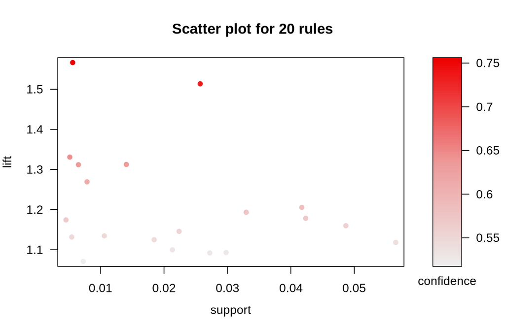

```r
plot(rules, measure=c("support","lift"), shading="confidence")
```

Based on the graph we have one or two points of interest with higher lift than the surrounding points. By adding the `interactive=TRUE` option to the `plot()` function we can select the datapoints for further exploration. It turns out these points are the ones below:

```r
inspect(head(rules,by="lift",n=2))
```

```
##     lhs                rhs      support     confidence lift     count
## [1] {Cake,Sandwich} => {Coffee} 0.005594194 0.7551020  1.566576  37
## [2] {Toast}         => {Coffee} 0.025703054 0.7296137  1.513697 170
```

Another somewhat useful plot is the Two-key plot

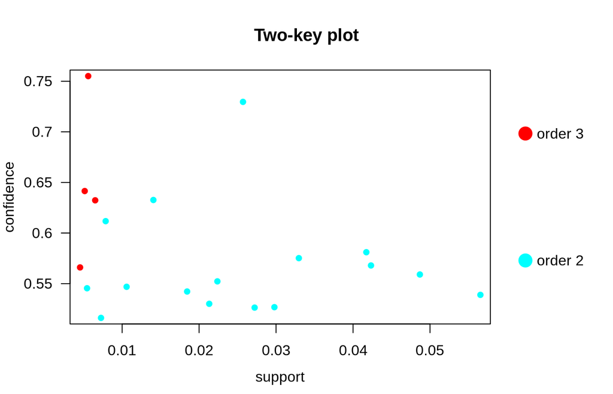

```r
plot(rules, method = "two-key plot")
```

We can use this to distinguish total items purchased. In this case we see most people buy only 2 items but 3 item purchases seem to have a higher confidence level.

There are other graphs available in the `arulesViz` library that I simply do not know how to properly use, and in some cases are not useful to us in this particular analysis.

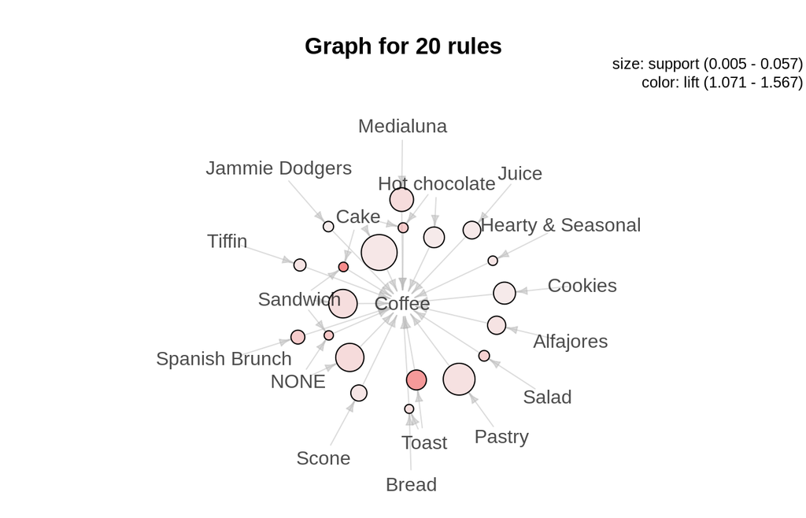

```r
plot(rules, method="graph")
```

The above graph is not useful in our situation but would have allowed us to visualize clusters of different RHS items if they existed. In our case almost everyone buys coffee with another item, so Coffee is the only clustered item. In a grocery store we might see many different clusters characterizing different shoppers.

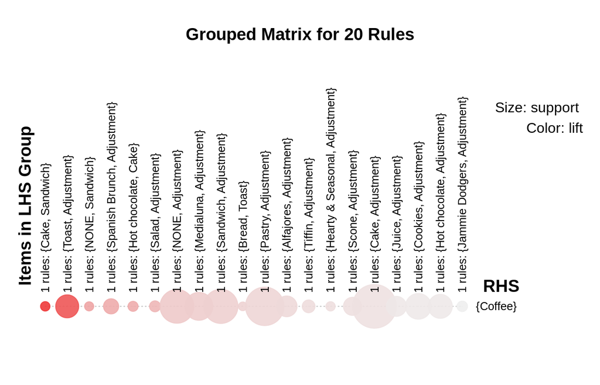

```r
plot(rules, method="grouped")
```

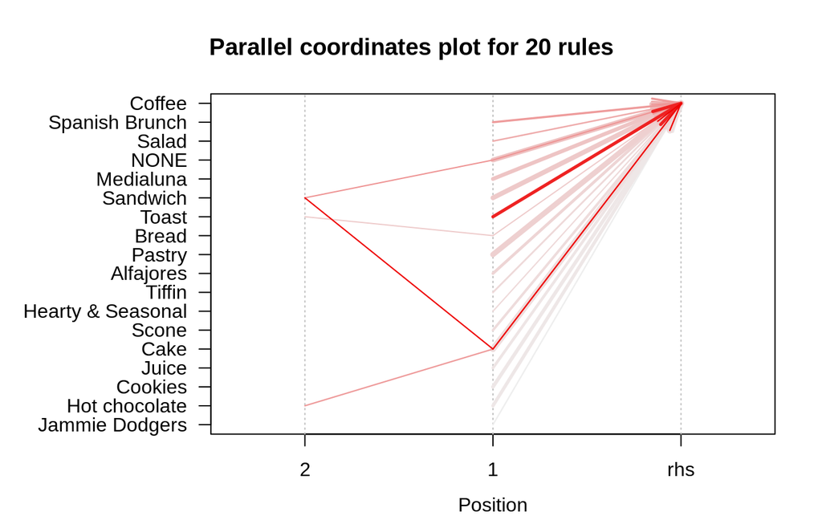

```r
plot(rules, method="paracoord", control=list(reorder=TRUE))
```

# 5 Conclusions

Taking a cursory look at the data and doing some relatively simple graphical analyses, we were able to discern which days were busiest, and at what times throughout the day that most transactions were taking place.

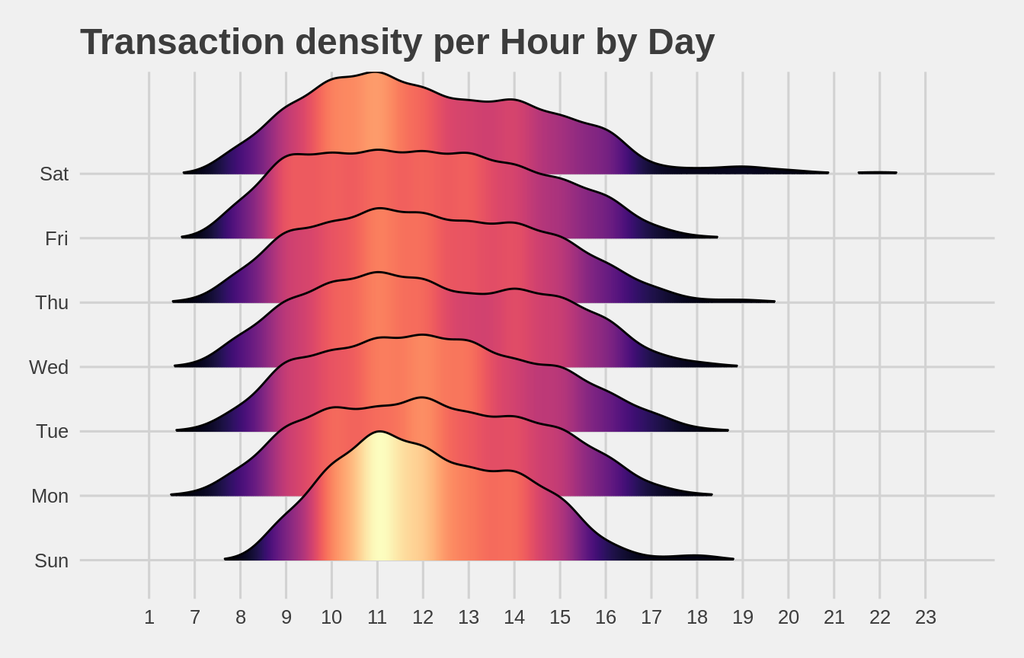

```r
x10
```

This data might be useful when scheduling staff and determining when additional staff is required, or when only minimal staff is needed. Of course, the bakery had probably already figured this out in a couple weeks of business. The graphical representation does give it a nice concrete feeling.

More useful is the number or items per transaction throughout the day.

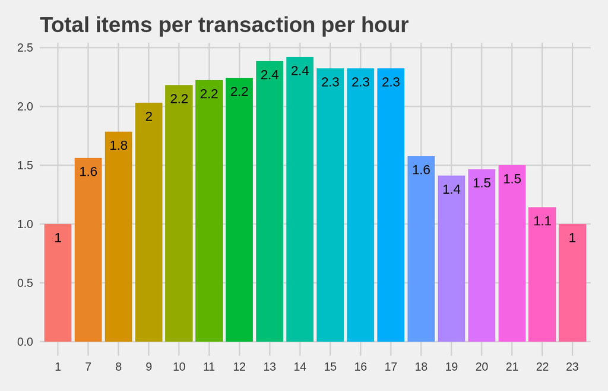

```r
x9
```

As a business we obviously want to sell more items. Some potential lines of action might be to incentivise the purhcase of additional items before 10am and after 5pm. Between the hours of 10am and 5pm we want to incentivise purchasing a 3rd item.

The Market Basket Analysis shows that {Toast} => {Coffee} is a common occurence. Also that {Cake, Sandwich} => {Coffee} has high lift and confidence but low support. We might increase the likelihood of a 3rd item purchased by introducing a Toast/Cake/Coffee or a Sandwich/Cake/Coffee special at discounted price.